# **Street View Housing Number Digit Recognition**

**by: Nicolás Salazar Beltrán ([nicolas-salbe.github.io](https://nicolas-salbe.github.io/))**

## **Context**

One of the most interesting tasks in deep learning is to recognize objects in natural scenes. The ability to process visual information using machine learning algorithms can be very useful as demonstrated in various applications.

The SVHN dataset contains over 600,000 labeled digits cropped from street-level photos. It is one of the most popular image recognition datasets. It has been used in neural networks created by Google to improve the map quality by automatically transcribing the address numbers from a patch of pixels. The transcribed number with a known street address helps pinpoint the location of the building it represents.

## **Objective**

Our objective is to predict the number depicted inside the image by using Artificial or Fully Connected Feed Forward Neural Networks and Convolutional Neural Networks. We will go through various models of each and finally select the one that is giving us the best performance.

## **Dataset**

Here, we will use a subset of the original data to save some computation time. The dataset is provided as a .h5 file. The basic preprocessing steps have been applied on the dataset.

## **Mount the drive**

Let us start by mounting the Google drive. You can run the below cell to mount the Google drive.

## **Importing the necessary libraries**

**Let us check the version of tensorflow.**

```
'2.12.0'
```

## **Load the dataset**

- Let us now load the dataset that is available as a .h5 file.
- Split the data into the train and the test dataset.

```
<class 'h5py._hl.files.File'>
```

```
<KeysViewHDF5 ['X_test', 'X_train', 'X_val', 'y_test', 'y_train', 'y_val']>
```

```
(18000, 32, 32)
```

Check the number of images in the training and the testing dataset.

```
(18000, 42000, 60000)
```

**Observation:**

- The testing dataset consists of 18k images.
- The training dataset consists of 42k images.
- The validation dataset consists of 60k images, which seems to correspond to the union of the testing and the training dasets. This means that there's no need to keep this dataset as all the training data is contained in *X_train*. The naming *validation* here can be misleading.

## **Visualizing images**

- Use X_train to visualize the first 10 images.
- Use Y_train to print the first 10 labels.

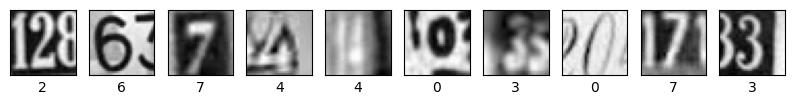

- Some images display more than one digit, so should the learning algorithm be capable of recognizing only the digit in the *center* of the image? Something to keep in mind...

```
[2 6 7 4 4 0 3 0 7 3]
```

## **Data preparation**

- Print the shape and the array of pixels for the first image in the training dataset.
- Normalize the train and the test dataset by dividing by 255.
- Print the new shapes of the train and the test dataset.
- One-hot encode the target variable.

```
shape: (32, 32)
content:
 [[ 33.0704  30.2601  26.852  ...  71.4471  58.2204  42.9939]
 [ 25.2283  25.5533  29.9765 ... 113.0209 103.3639  84.2949]
 [ 26.2775  22.6137  40.4763 ... 113.3028 121.775  115.4228]
 ...
 [ 28.5502  36.212   45.0801 ...  24.1359  25.0927  26.0603]
 [ 38.4352  26.4733  23.2717 ...  28.1094  29.4683  30.0661]
 [ 50.2984  26.0773  24.0389 ...  49.6682  50.853   53.0377]]
```

### **Normalize the train and the test data**

```
shape: (32, 32)
content:
 [[0.12968785 0.11866706 0.10530196 ... 0.2801847  0.2283153  0.16860352]
 [0.09893451 0.10020902 0.1175549  ... 0.4432192  0.40534863 0.33056822]
 [0.10304902 0.08868118 0.15873058 ... 0.44432473 0.47754902 0.45263842]
 ...
 [0.11196157 0.14200786 0.17678471 ... 0.09465059 0.09840274 0.10219726]
 [0.15072627 0.10381687 0.09126157 ... 0.11023294 0.11556196 0.11790627]
 [0.19724864 0.10226392 0.0942702  ... 0.19477727 0.19942354 0.20799099]]
```

Print the shapes of Training and Test data

```
(42000, 32, 32)
(18000, 32, 32)
```

### **One-hot encode output**

```
y_train shape before one-hot encoding: (42000,)
```

```
y_train shape after one-hot encoding: (42000, 10)
```

```
array([[0., 0., 1., ..., 0., 0., 0.],
       [0., 0., 0., ..., 0., 0., 0.],
       [0., 0., 0., ..., 1., 0., 0.],
       ...,
       [0., 0., 0., ..., 1., 0., 0.],
       [1., 0., 0., ..., 0., 0., 0.],
       [0., 0., 0., ..., 0., 0., 0.]], dtype=float32)
```

**Observation:**

- Data normalization is just a rescaling so it doesn't affect the original shapes of the independent variable arrays.
- The dependent variable data is no longer an array of integers corresponding to the digit labels but an array of 10-elements arrays, each of which encodes the original digit label with a *1* in the corresponding array position.

## **Model Building**

Now that we have done the data preprocessing, let's build an ANN model.

### Fix the seed for random number generators

### **Model Architecture**

- Write a function that returns a sequential model with the following architecture:
  - First hidden layer with **64 nodes and the relu activation** and the **input shape = (1024, )**
  - Second hidden layer with **32 nodes and the relu activation**
  - Output layer with **activation as 'softmax' and number of nodes equal to the number of classes, i.e., 10**
  - Compile the model with the **loss equal to categorical_crossentropy, optimizer equal to Adam(learning_rate = 0.001), and metric equal to 'accuracy'**. Do not fit the model here, just return the compiled model.
- Call the nn_model_1 function and store the model in a new variable.
- Print the summary of the model.
- Fit on the train data with a **validation split of 0.2, batch size = 128, verbose = 1, and epochs = 20**. Store the model building history to use later for visualization.

### **Build and train an ANN model as per the above mentioned architecture.**

```
Model: "sequential"
_________________________________________________________________
 Layer (type)                Output Shape              Param #
=================================================================
 dense (Dense)               (None, 64)                65600

 dense_1 (Dense)             (None, 32)                2080

 dense_2 (Dense)             (None, 10)                330

=================================================================
Total params: 68,010
Trainable params: 68,010
Non-trainable params: 0
_________________________________________________________________
```

```
(42000, 1024)
```

```
(18000, 1024)
```

### **Plot the Training and Validation Accuracies and write down your Observations.**

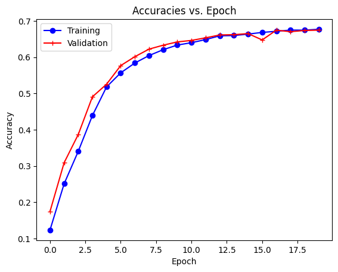

**Observations:**___****

- The behavior of the training and the validation accuracies as the fitting progresses is very similar, indicating that the model is not overfitting.
- After 20 epochs, both accuracies seem to be settling down around 0.67. In order to deal with this low performance we may increase the complexity of the ANN architecture. Increasing the number of epochs won't make much difference.
- The architecture of model_1 is not very complex and therefore the fitting is not too computationally demanding.

Let's build one more model with higher complexity and see if we can improve the performance of the model.

First, we need to clear the previous model's history from the Keras backend. Also, let's fix the seed again after clearing the backend.

### **Second Model Architecture**

- Write a function that returns a sequential model with the following architecture:
  - First hidden layer with **256 nodes and the relu activation** and the **input shape = (1024, )**
  - Second hidden layer with **128 nodes and the relu activation**
  - Add the **Dropout layer with the rate equal to 0.2**
  - Third hidden layer with **64 nodes and the relu activation**
  - Fourth hidden layer with **64 nodes and the relu activation**
  - Fifth hidden layer with **32 nodes and the relu activation**
  - Add the **BatchNormalization layer**
  - Output layer with **activation as 'softmax' and number of nodes equal to the number of classes, i.e., 10** -Compile the model with the **loss equal to categorical_crossentropy, optimizer equal to Adam(learning_rate = 0.0005), and metric equal to 'accuracy'**. Do not fit the model here, just return the compiled model.
- Call the nn_model_2 function and store the model in a new variable.
- Print the summary of the model.
- Fit on the train data with a **validation split of 0.2, batch size = 128, verbose = 1, and epochs = 30**. Store the model building history to use later for visualization.

### **Build and train the new ANN model as per the above mentioned architecture**

```
Model: "sequential"
_________________________________________________________________
 Layer (type)                Output Shape              Param #
=================================================================
 dense (Dense)               (None, 256)               262400

 dense_1 (Dense)             (None, 128)               32896

 dropout (Dropout)           (None, 128)               0

 dense_2 (Dense)             (None, 64)                8256

 dense_3 (Dense)             (None, 64)                4160

 dense_4 (Dense)             (None, 32)                2080

 batch_normalization (BatchN  (None, 32)               128
 ormalization)

 dense_5 (Dense)             (None, 10)                330

=================================================================
Total params: 310,250
Trainable params: 310,186
Non-trainable params: 64
_________________________________________________________________
```

### **Plot the Training and Validation Accuracies and write down your Observations.**

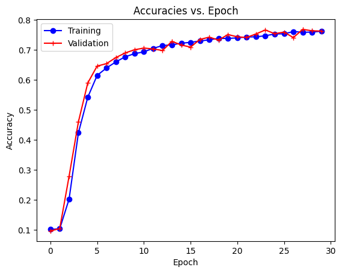

**Observations:**___****

- As in model_1, the training and validation accuracies go hand by hand in model_2. This suggests that the model is not overfitting.
- model_2 shows an increase in performance in comparison to model_1 as the accuracies after 9 epochs are already similar to those in model_1. As the fitting progresses the accuracies increase up to around 0.76 after 30 epochs.
- The accuracies after 30 epochs seem to be settling down, which suggests that the fitting is close to converge.
- model_2 is much more complex than model_1, which reflects on the increased computation time (the amount of parameters to train is more than 4 times that of model_1)

## **Predictions on the test data**

- Make predictions on the test set using the second model.
- Print the obtained results using the classification report and the confusion matrix.
- Final observations on the obtained results.

```
array([2, 7, 2, ..., 7, 9, 2])
```

**Note:** Earlier, we noticed that each entry of the target variable is a one-hot encoded vector but to print the classification report and confusion matrix, we must convert each entry of y_test to a single label.

- *The above note doesn't apply to this notebook as y_test was never one-hot encoded.*

```
array([1, 7, 2, ..., 7, 9, 2], dtype=uint8)
```

### **Print the classification report and the confusion matrix for the test predictions. Write your observations on the final results.**

```
Classification Report:

              precision    recall  f1-score   support

           0       0.84      0.75      0.79      1814
           1       0.74      0.79      0.77      1828
           2       0.77      0.80      0.79      1803
           3       0.62      0.77      0.69      1719
           4       0.79      0.83      0.81      1812
           5       0.76      0.68      0.72      1768
           6       0.80      0.74      0.77      1832
           7       0.83      0.77      0.80      1808
           8       0.72      0.72      0.72      1812
           9       0.75      0.74      0.75      1804

    accuracy                           0.76     18000
   macro avg       0.76      0.76      0.76     18000
weighted avg       0.76      0.76      0.76     18000
```

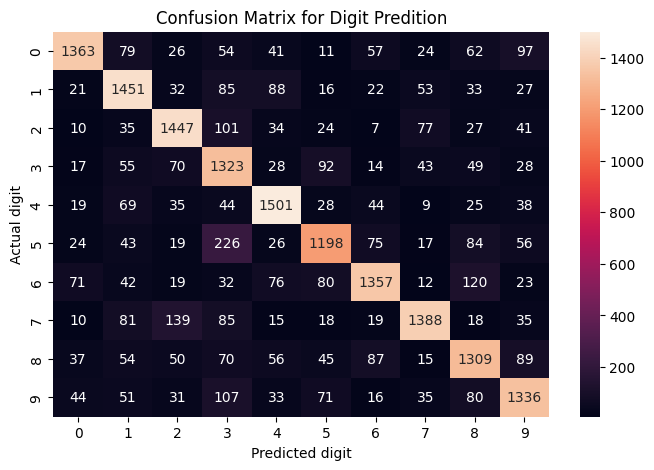

**Final Observations:**__****

- For digit detection precision and recall can be considered equally important. Therefore, the f1-score is a better metric for comparison. Overall, digit *3* is the most difficult digit to detect while digit *4* is the easiest.
- Digit *3* is proportionally the least precisely detected digit, meaning that it leads to more false positives. Contrarily, digit *0* is the most precisely detected digit.
- Digit *5* is proportionally the least recalled digit, meaning that it leads to more false negatives. Contrarily, digit *4* is the most recalled digit.
- Digit *5* is more often misclassified as a *3*. This could be due to the model having problems to detect some edges.
- The overall detection accuracy *0.76* of X_test is practically the same as that of X_train, indicating that model_2 does generalize the fitting well.
- From the support column it can be seen that samples for each class are pretty much balanced. Interestingly, digit *3* and digit *5* are the classes least represented. This could also explain their low detection scores in comparison with other digits as the model has less data to learn their corresponding parameters.
- In general, model_2 has a fairly good accuracy suitable for applications that can tolerate wrong detections every now or then. For more demanding applications there's still room for improvement.

## **Using Convolutional Neural Networks**

### **Load the dataset again and split the data into the train and the test dataset.**

Check the number of images in the training and the testing dataset.

```
(18000, 42000)
```

**Observation:**

- There are 18k images in the testing dataset and 42k images in the training dataset.

## **Data preparation**

- Print the shape and the array of pixels for the first image in the training dataset.
- Reshape the train and the test dataset because we always have to give a 4D array as input to CNNs.
- Normalize the train and the test dataset by dividing by 255.
- Print the new shapes of the train and the test dataset.
- One-hot encode the target variable.

```
shape: (32, 32)
content:
 [[ 33.0704  30.2601  26.852  ...  71.4471  58.2204  42.9939]
 [ 25.2283  25.5533  29.9765 ... 113.0209 103.3639  84.2949]
 [ 26.2775  22.6137  40.4763 ... 113.3028 121.775  115.4228]
 ...
 [ 28.5502  36.212   45.0801 ...  24.1359  25.0927  26.0603]
 [ 38.4352  26.4733  23.2717 ...  28.1094  29.4683  30.0661]
 [ 50.2984  26.0773  24.0389 ...  49.6682  50.853   53.0377]]
```

Reshape the dataset to be able to pass them to CNNs. Remember that we always have to give a 4D array as input to CNNs

Normalize inputs from 0-255 to 0-1

Print New shape of Training and Test

```
(42000, 32, 32, 1)
(18000, 32, 32, 1)
```

### **One-hot encode the labels in the target variable y_train and y_test.**

```
y_train shape before one-hot encoding: (42000,)
y_train shape after one-hot encoding: (42000, 10)
```

- *Since y_test is not used for training the model it is not necessary to one-hot encode it.*

**Observation:**

- Data normalization is just a rescaling so it doesn't affect the original shapes of the independent variable arrays.
- y_train is no longer an array of integers corresponding to the digit labels but an array of 10-elements arrays, each of which encodes the original digit label with a *1* in the corresponding array position.

## **Model Building**

Now that we have done data preprocessing, let's build a CNN model. Fix the seed for random number generators

### **Model Architecture**

- **Write a function** that returns a sequential model with the following architecture:
  - First Convolutional layer with **16 filters and the kernel size of 3x3**. Use the **'same' padding** and provide the **input shape = (32, 32, 1)**
  - Add a **LeakyRelu layer** with the **slope equal to 0.1**
  - Second Convolutional layer with **32 filters and the kernel size of 3x3 with 'same' padding**
  - Another **LeakyRelu** with the **slope equal to 0.1**
  - A **max-pooling layer** with a **pool size of 2x2**
  - **Flatten** the output from the previous layer
  - Add a **dense layer with 32 nodes**
  - Add a **LeakyRelu layer with the slope equal to 0.1**
  - Add the final **output layer with nodes equal to the number of classes, i.e., 10** and **'softmax' as the activation function**
  - Compile the model with the **loss equal to categorical_crossentropy, optimizer equal to Adam(learning_rate = 0.001), and metric equal to 'accuracy'**. Do not fit the model here, just return the compiled model.
- Call the function cnn_model_1 and store the output in a new variable.
- Print the summary of the model.
- Fit the model on the training data with a **validation split of 0.2, batch size = 32, verbose = 1, and epochs = 20**. Store the model building history to use later for visualization.

### **Build and train a CNN model as per the above mentioned architecture.**

```
Model: "sequential"
_________________________________________________________________
 Layer (type)                Output Shape              Param #
=================================================================
 conv2d (Conv2D)             (None, 32, 32, 16)        160

 leaky_re_lu (LeakyReLU)     (None, 32, 32, 16)        0

 conv2d_1 (Conv2D)           (None, 32, 32, 32)        4640

 leaky_re_lu_1 (LeakyReLU)   (None, 32, 32, 32)        0

 max_pooling2d (MaxPooling2D  (None, 16, 16, 32)       0
 )

 flatten (Flatten)           (None, 8192)              0

 dense (Dense)               (None, 32)                262176

 leaky_re_lu_2 (LeakyReLU)   (None, 32)                0

 dense_1 (Dense)             (None, 10)                330

=================================================================
Total params: 267,306
Trainable params: 267,306
Non-trainable params: 0
_________________________________________________________________
```

### **Plot the Training and Validation Accuracies and Write your observations.**

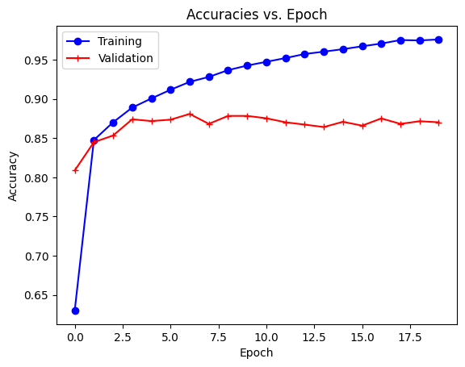

Let's build another model and see if we can get a better model with generalized performance.

First, we need to clear the previous model's history from the Keras backend. Also, let's fix the seed again after clearing the backend.

### **Second Model Architecture**

- Write a function that returns a sequential model with the following architecture:
  - First Convolutional layer with **16 filters and the kernel size of 3x3**. Use the **'same' padding** and provide the **input shape = (32, 32, 1)**
  - Add a **LeakyRelu layer** with the **slope equal to 0.1**
  - Second Convolutional layer with **32 filters and the kernel size of 3x3 with 'same' padding**
  - Add **LeakyRelu** with the **slope equal to 0.1**
  - Add a **max-pooling layer** with a **pool size of 2x2**
  - Add a **BatchNormalization layer**
  - Third Convolutional layer with **32 filters and the kernel size of 3x3 with 'same' padding**
  - Add a **LeakyRelu layer with the slope equal to 0.1**
  - Fourth Convolutional layer **64 filters and the kernel size of 3x3 with 'same' padding**
  - Add a **LeakyRelu layer with the slope equal to 0.1**
  - Add a **max-pooling layer** with a **pool size of 2x2**
  - Add a **BatchNormalization layer**
  - **Flatten** the output from the previous layer
  - Add a **dense layer with 32 nodes**
  - Add a **LeakyRelu layer with the slope equal to 0.1**
  - Add a **dropout layer with the rate equal to 0.5**
  - Add the final **output layer with nodes equal to the number of classes, i.e., 10** and **'softmax' as the activation function**
  - Compile the model with the **categorical_crossentropy loss, adam optimizers (learning_rate = 0.001), and metric equal to 'accuracy'**. Do not fit the model here, just return the compiled model.
- Call the function cnn_model_2 and store the model in a new variable.
- Print the summary of the model.
- Fit the model on the train data with a **validation split of 0.2, batch size = 128, verbose = 1, and epochs = 30**. Store the model building history to use later for visualization.

### **Build and train the second CNN model as per the above mentioned architecture.**

```
Model: "sequential"
_________________________________________________________________
 Layer (type)                Output Shape              Param #
=================================================================
 conv2d (Conv2D)             (None, 32, 32, 16)        160

 leaky_re_lu (LeakyReLU)     (None, 32, 32, 16)        0

 conv2d_1 (Conv2D)           (None, 32, 32, 32)        4640

 leaky_re_lu_1 (LeakyReLU)   (None, 32, 32, 32)        0

 max_pooling2d (MaxPooling2D  (None, 16, 16, 32)       0
 )

 batch_normalization (BatchN  (None, 16, 16, 32)       128
 ormalization)

 conv2d_2 (Conv2D)           (None, 16, 16, 32)        9248

 leaky_re_lu_2 (LeakyReLU)   (None, 16, 16, 32)        0

 conv2d_3 (Conv2D)           (None, 16, 16, 64)        18496

 leaky_re_lu_3 (LeakyReLU)   (None, 16, 16, 64)        0

 max_pooling2d_1 (MaxPooling  (None, 8, 8, 64)         0
 2D)

 batch_normalization_1 (Batc  (None, 8, 8, 64)         256
 hNormalization)

 flatten (Flatten)           (None, 4096)              0

 dense (Dense)               (None, 32)                131104

 leaky_re_lu_4 (LeakyReLU)   (None, 32)                0

 dropout (Dropout)           (None, 32)                0

 dense_1 (Dense)             (None, 10)                330

=================================================================
Total params: 164,362
Trainable params: 164,170
Non-trainable params: 192
_________________________________________________________________
```

### **Plot the Training and Validation accuracies and write your observations.**

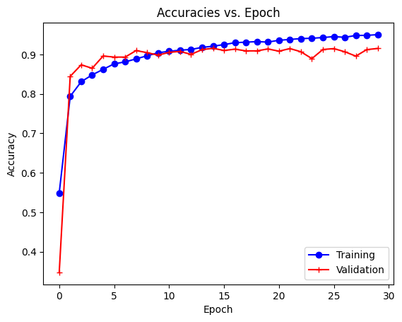

## **Predictions on the test data**

- Make predictions on the test set using the second model.
- Print the obtained results using the classification report and the confusion matrix.
- Final observations on the obtained results.

### **Make predictions on the test data using the second model.**

```
array([1, 7, 2, ..., 7, 3, 2])
```

**Note:** Earlier, we noticed that each entry of the target variable is a one-hot encoded vector, but to print the classification report and confusion matrix, we must convert each entry of y_test to a single label.

- *This is not necessary in this notebook as y_test was not one-hot encoded before.*

```
array([1, 7, 2, ..., 7, 9, 2], dtype=uint8)
```

### **Write your final observations on the performance of the model on the test data.**

```
Classification Report:

              precision    recall  f1-score   support

           0       0.90      0.95      0.93      1814
           1       0.89      0.93      0.91      1828
           2       0.94      0.90      0.92      1803
           3       0.90      0.89      0.89      1719
           4       0.94      0.92      0.93      1812
           5       0.90      0.92      0.91      1768
           6       0.92      0.88      0.90      1832
           7       0.92      0.94      0.93      1808
           8       0.93      0.88      0.90      1812
           9       0.90      0.92      0.91      1804

    accuracy                           0.91     18000
   macro avg       0.91      0.91      0.91     18000
weighted avg       0.91      0.91      0.91     18000
```

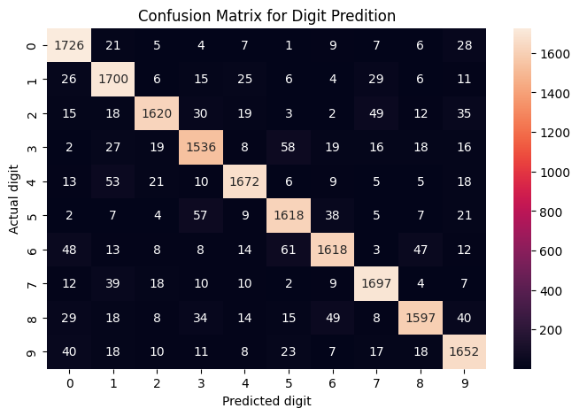

**Final Observations:**_****

- Overall, digit *3* is the most difficult digit to detect. However, in comparison with model_2 the score gap between detecting a *3* and other digits is much smaller.
- With a minimum f1-score of 0.89 (digit *3*) cnn_model_2 does a very good job at detecting every digit in the dataset.
- Digits *0*, *4*, and *7* can be thought to be equally as easy to detect.
- Digit *1* is proportionally the least precisely detected digit, meaning that it leads to more false positives. Contrarily, digit *2* is the most precisely detected digit.
- Digits *6* and *8* are proportionally the least recalled digit, meaning that they lead to more false negatives. Contrarily, digit *0* is the most recalled digit.
- The overall detection accuracy 0.91 of X_test is a bit off from the training accuracy of X_train (0.95). This confirms that cnn_model_2 has some room for improvement to better generalize the fitting.
- In general, cnn_model_2 has a good accuracy suitable for applications that can tolerate an overall 9% misclassification error.

## **Conclusions**

- For this digit detection task ANNs can achieve a discrete performance with no much architecture complexity. However, in order to achieve much better performance it is evident that CNNs are the way forward.
- With half the parameters of model_2, cnn_model_2 achieved a much better accuracy. This indicates the convenience of feature extraction through convolution rather than mass learning a pattern with a fully connected ANN.
- For images displaying more than one digit, the predicted digit seems to be the one in the center. This is something learnt by the models due to the labels themselves. Question remains whether this is a design choice.
- Digits *3* and *5* are the most challenging to detect most likely because they are slightly under-represented in the dataset.
- Some further improvements to deal with cnn_model_2 overfitting can include adding more regularization layers with Batch Normalization or Dropout or considering an optimizer with weight decay.
- If more accuracy is required without adding more data then some options are to try other optimizers that may lead to more closely reaching the minimima of the loss function. Otherwise, an improvement of the architecture with transfer learning may also provide great results.